# Support for Female Clergy

Ryan Burge

August 11, 2017

## The Data

I scoured all the resources that I could find and there are not many surveys that I have access to that ask a specific question about women in ministry. The best I could come up with is the [Faith Matters Survey](http://www.thearda.com/Archive/Files/Descriptions/FTHMATT.asp) which was conducted in 2006. I tried to pick out some of the most relevant predictors of what would change someone’s opinion of female clergy. Feel free to read through the [codebook](http://www.thearda.com/Archive/Files/Codebooks/FTHMATT_CB.asp) and look for other relevant questions if you like and I can provide some analysis.

## Overview

The question is posed this way: “Women should be allowed to be priests or clergy in my house of worship?” Respondents are given the option to respond from Strongly Agree to Strongly Disagree.

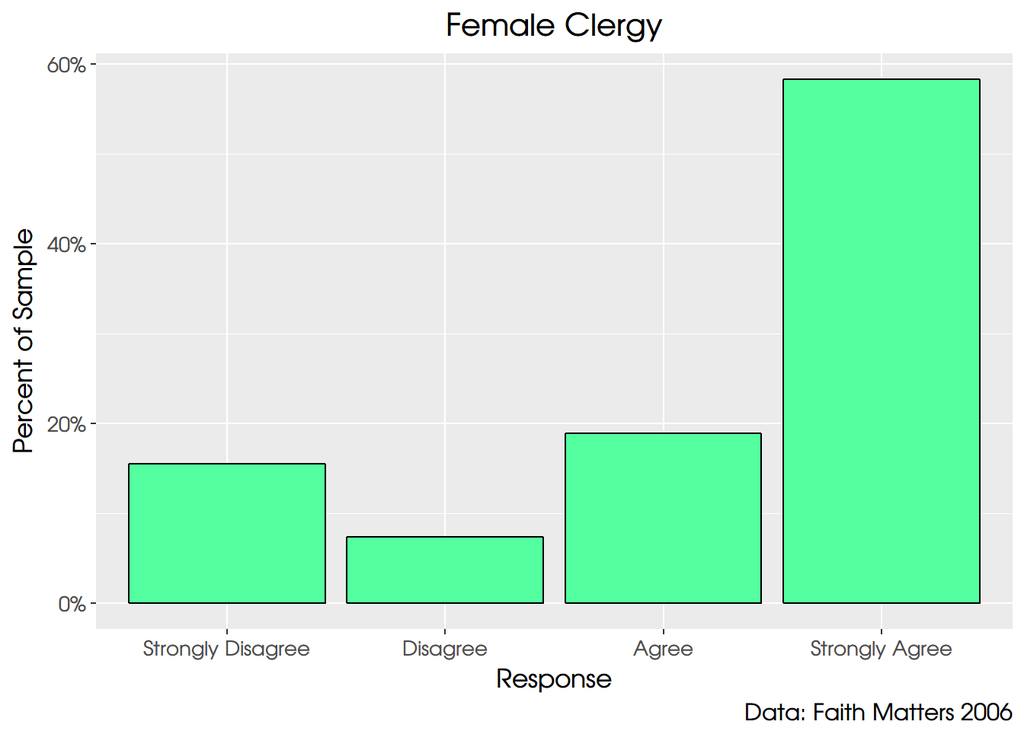

Here’s the good news. About 76% of the total sample agrees that women should have the ability to be a priest or member of the clergy. That’s way higher than I even thought. So, over 2/3 of Americans are fine with female clergy.

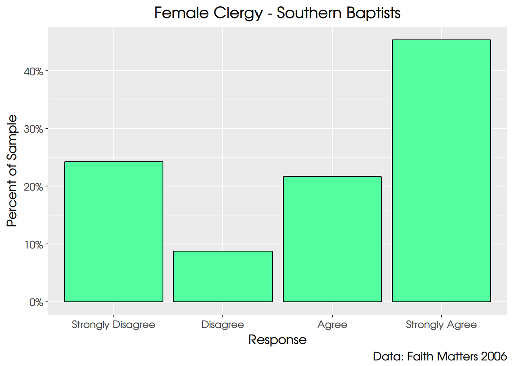

Even members of the SBC are supportive of female clergy. 67% of SBC members were in favor.

## Gender

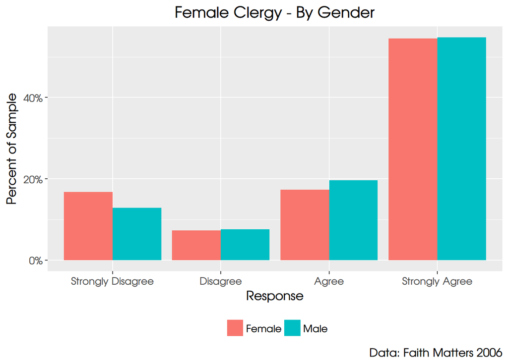

I wanted to break this down by gender. There isn’t a whole lot of difference between men and women. However, female respondents were actually slightly MORE likely to strongly disagree that women should be pastors. Which is somewhat surprising.

## Party Identification

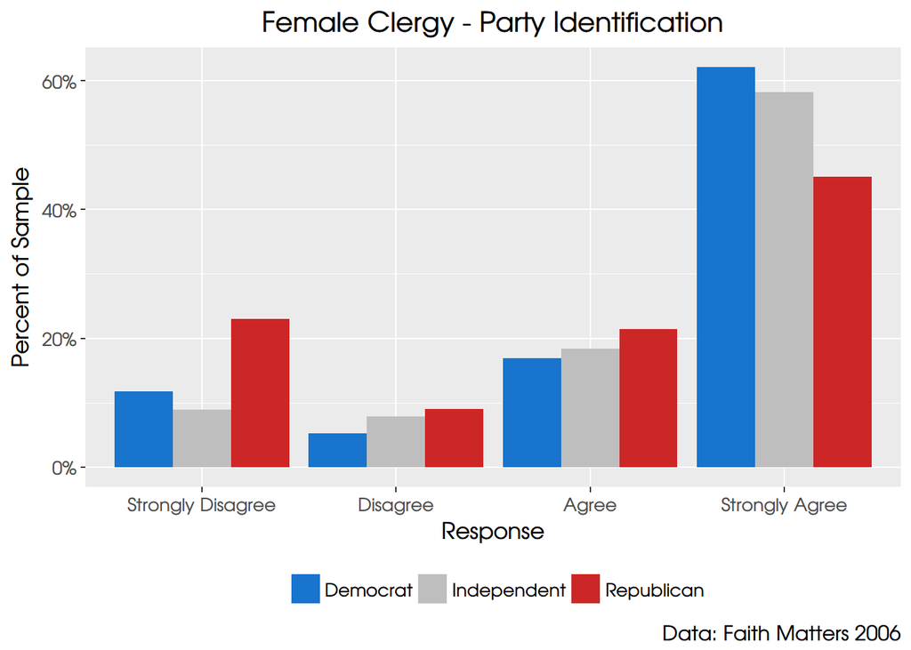

When looking at this from a political angle, the trend is fairly apparent. Democrats are more likely to be in favor of female clergy, Republicans are less likely. That’s probably because ideology and theology run are strongly correlated.

## Gay Marriage

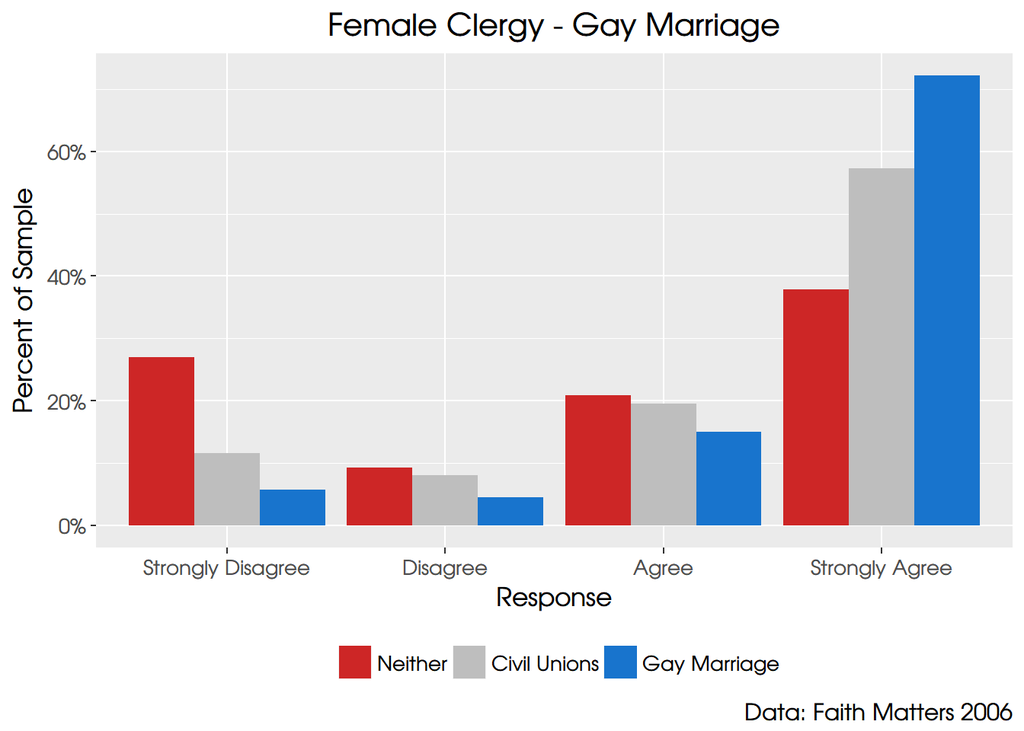

This looks a lot like the previous graph. Here’s something that is interesting: Only 35% of people whoo are opposed to gay marriage are opposed to female clergy. So, there’s really not a huge wall of opposition.

## Church Attendance

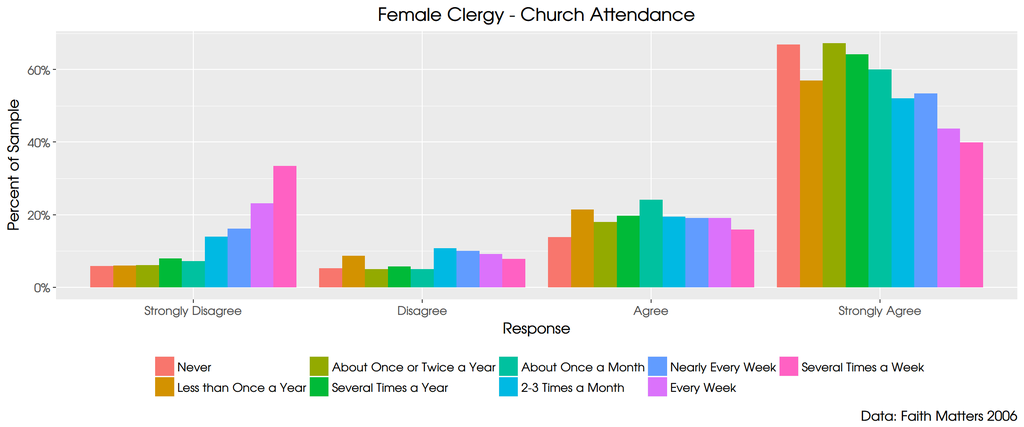

Here the opposition is made clear. About 55% of those who attend several times a week are in favor of female clergy. It’s 62% of those who attend every week.

However, consider than in both of theses groups, a majority of them are still in favor of female clergy. There’s a lot of support, overall.

## Concluding Thoughts

People, generally, feel pretty positive about allowing female to become clergy. Even among Southern Baptists! There’s a lot of literature out there about the laity in most denominations are much more liberal on theology than the church hierarchy. This is especially apparent in the Catholic church. I just checked and 75% of Catholics are in favor of female priests. So, it’s the church structure that is holding things back. Patriarchy is hard to overturn.